# Final report group 5

Toprak, Siren, Cathrine

2024-09-13

## Original data

The data comes from Diabetes Prediction Dataset from the Pima Indian Tribe and the NIDDK, [here are details](https://github.com/toprakd/group5/blob/main/DATA/codebook_updated).

### READING DATA

We read the data. In the beginning, the data were as shown.

```r
exam_nontidy
```

```
## # A tibble: 1,686 × 11
##    subject   `pregnancy_num-age` triceps_mm `insulin microiu ml`   bmi pedigree
##    <chr>     <chr>                    <dbl>                <dbl> <dbl>    <dbl>
##  1 Hosp3-208 5-52                        NA                   NA  37.7    0.151
##  2 Hosp3-232 6-46                        37                  370  46.2    0.238
##  3 Hosp2-90  1-24                        19                   NA  26.5    0.165
##  4 Hosp3-263 4-24                        32                   NA  32.1    0.612
##  5 Hosp2-98  1-22                        18                   76  20.4    0.323
##  6 Hosp3-469 8-38                        NA                   NA  30      0.183
##  7 Hosp3-571 3-39                        NA                   NA  32.5    0.27
##  8 Hosp3-662 1-22                        43                   NA  42.9    1.39
##  9 Hosp3-627 0-21                        NA                   NA  24.7    0.206
## 10 Hosp3-634 1-22                        17                  183  27.5    0.115
## # ℹ 1,676 more rows
## # ℹ 5 more variables: `5y diabetes` <chr>, choleste <dbl>, sibling <lgl>,
## #   `measured variable` <chr>, .value <dbl>
```

## TIDYING THE DATA

To tidy the data, we had to:

- remove duplicated rows
- rename coloumns that contain spaces or start with numbers
- separate subject and “pregnancy_num-age” coloumns into two
- create to new coloums called “glucose_mg_dl” and “dbp_mm_hg” because the “.value” coloumn was including values from both features

```r
#Changing the names of coloumns:
exam_nontidy <-
  exam_nontidy %>%
  rename(insulin_microiu_ml = `insulin microiu ml`,
         diabetes_5_year = `5y diabetes`,
         cholesterol = choleste)

#Separate variable subject into "hospital" and "ID":
df <- separate(exam_nontidy, subject, sep ="-",
               into = c("hospital", "ID"))

#Separate variable "pregnancy_num-ag"e into "pregnancy_num" and "age":
df1 <- separate(df, "pregnancy_num-age", sep ="-",
                into = c("preg_num", "age"))

#remove duplicates and pivot wider (for the measured variable and the ".value" coloumn):
tidy_data <- df1 %>%
  distinct() %>%
  pivot_wider(names_from = `measured variable`,
              values_from = .value)
```

## WRANGLING THE DATA

We did the following steps to further tidy our data:

- remove unnecessary “cholesterol” and “sibling” columns
- correct the variable types
- adding a numeric column showing insulin in units pmol/L (1 microiu_ml = 6.945 pmol_l)
- adding a column showing `diabetes_5_year` as 0/1
- adding a numeric column showing multiplication of `age` and `pregnancy_num` for each person
- setting the order of columns as: `ID, hospital, age` and other columns
- arranged ID column of the dataset in order of increasing number

Then we merged our dataset with an additional dataset (exam_joindata). [Here are details for the additional data](https://github.com/toprakd/group5/blob/main/DATA/exam_joindata.txt.).

```r
tidy_data <- tidy_data %>%
  select(- cholesterol, - sibling)  %>%
  mutate(across(ID:age, as.numeric)) %>%
  mutate(glucose_mg_dl_categoric = ifelse(glucose_mg_dl >120, "High", "Low"),
         insulin_pmol_L = insulin_microiu_ml * 6.945,
         diabetes_5_year_binary= ifelse(diabetes_5_year== "neg",0,1),
         multiplication_age_and_pregnancy_num= preg_num*age) %>%
  select(ID, hospital, age, everything()) %>%
  arrange(ID) %>%
  full_join(join_data, join_by("ID"))
```

Summary and overview of our data: After all of the data preparation steps, our final data looked like this:

```
## # A tibble: 768 × 16
##       ID hospital   age preg_num triceps_mm insulin_microiu_ml   bmi pedigree
##    <dbl> <chr>    <dbl>    <dbl>      <dbl>              <dbl> <dbl>    <dbl>
##  1     1 Hosp1       50        6         35                 NA  33.6    0.627
##  2     2 Hosp1       31        1         29                 NA  26.6    0.351
##  3     3 Hosp1       32        8         NA                 NA  23.3    0.672
##  4     4 Hosp1       21        1         23                 94  28.1    0.167
##  5     5 Hosp1       33        0         35                168  43.1    2.29
##  6     6 Hosp1       30        5         NA                 NA  25.6    0.201
##  7     7 Hosp1       26        3         32                 88  31      0.248
##  8     8 Hosp1       29       10         NA                 NA  35.3    0.134
##  9     9 Hosp1       53        2         45                543  30.5    0.158
## 10    10 Hosp1       54        8         NA                 NA  NA      0.232
## # ℹ 758 more rows
## # ℹ 8 more variables: diabetes_5_year <chr>, glucose_mg_dl <dbl>,
## #   dbp_mm_hg <dbl>, glucose_mg_dl_categoric <chr>, insulin_pmol_L <dbl>,
## #   diabetes_5_year_binary <dbl>, multiplication_age_and_pregnancy_num <dbl>,
## #   antibody <dbl>
```

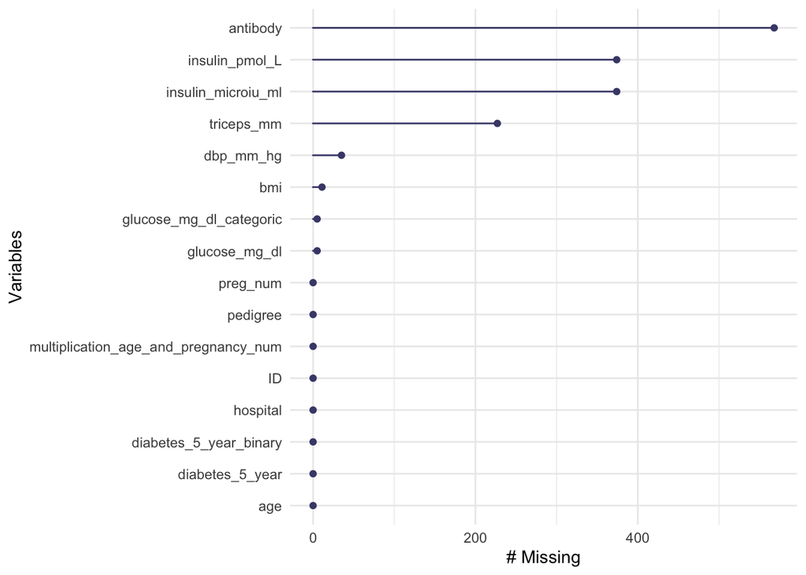

### Stratification

Then we did the following stratification to explore our data:

- Pregnancy numbers in different hospitals

```
## # A tibble: 3 × 5
##   hospital `min(preg_num)` `max(preg_num)` `mean(preg_num)` `sd(preg_num)`
##   <chr>              <dbl>           <dbl>            <dbl>          <dbl>
## 1 Hosp1                  0              13             4.83           3.53
## 2 Hosp2                  0              17             3.68           3.21
## 3 Hosp3                  0              14             3.75           3.37
```

- Pregnancy numbers in different hospitals filtered by “diabetes_5_year” positive patiens

```
## # A tibble: 3 × 5
##   hospital `min(preg_num)` `max(preg_num)` `mean(preg_num)` `sd(preg_num)`
##   <chr>              <dbl>           <dbl>            <dbl>          <dbl>
## 1 Hosp1                  0              13             5.66           3.67
## 2 Hosp2                  0              17             4.92           4.17
## 3 Hosp3                  0              14             4.73           3.67
```

- Pregnancy numbers in Hospital 1

```
## # A tibble: 1 × 5
##   hospital `min(preg_num)` `max(preg_num)` `mean(preg_num)` `sd(preg_num)`
##   <chr>              <dbl>           <dbl>            <dbl>          <dbl>
## 1 Hosp1                  0              13             4.83           3.53
```

- Only for persons with `pregnanyc_num` more than 2

```
## # A tibble: 3 × 5
##   hospital `min(preg_num)` `max(preg_num)` `mean(preg_num)` `sd(preg_num)`
##   <chr>              <dbl>           <dbl>            <dbl>          <dbl>
## 1 Hosp1                  3              13             6.86           2.60
## 2 Hosp2                  3              17             5.92           2.76
## 3 Hosp3                  3              14             6.20           2.81
```

- For `glucose_mg_dl` lower than 120 and `dbp_mm_hg` greater than 60

```
## # A tibble: 3 × 5
##   hospital `min(preg_num)` `max(preg_num)` `mean(preg_num)` `sd(preg_num)`
##   <chr>              <dbl>           <dbl>            <dbl>          <dbl>
## 1 Hosp1                  0               9             3.65           2.89
## 2 Hosp2                  0              13             3.60           3.12
## 3 Hosp3                  0              14             3.61           3.39
```

- Patient numbers according to different hospitals and diabetes status

```
## # A tibble: 6 × 3
## # Groups:   hospital [3]
##   hospital diabetes_5_year count
##   <chr>    <chr>           <int>
## 1 Hosp1    neg                43
## 2 Hosp1    pos                32
## 3 Hosp2    neg                78
## 4 Hosp2    pos                37
## 5 Hosp3    neg               379
## 6 Hosp3    pos               199
```

## PLOTS

We made 6 plots to check if there was any correlated measurements:

### Plot 1: Correlation matrix

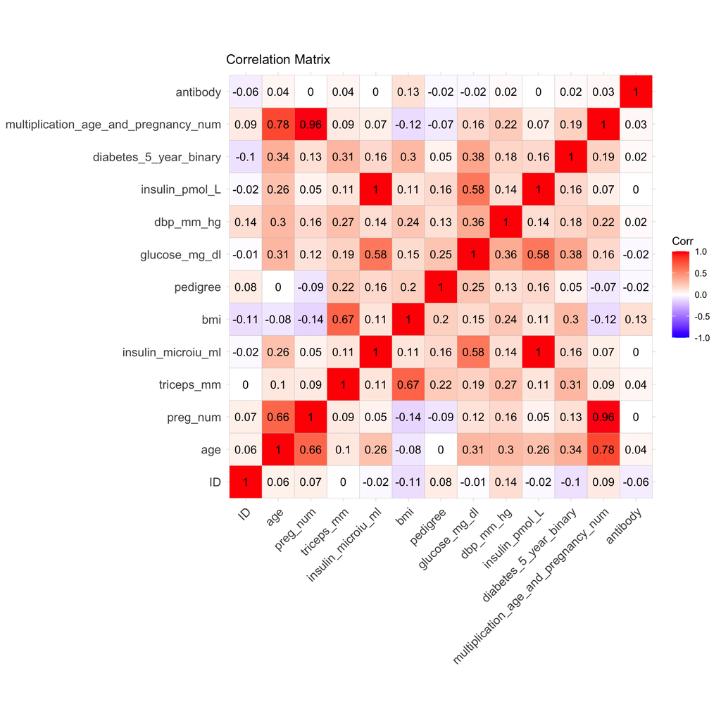

In the correlation matrix we mostly saw positive correlations. Especially, “glucose_mg_dl” and “insulin_microiu_ml” correlated, and bmi and “triceps_mm” were correlated.

### Plot 2: The level of glucose vs insulin

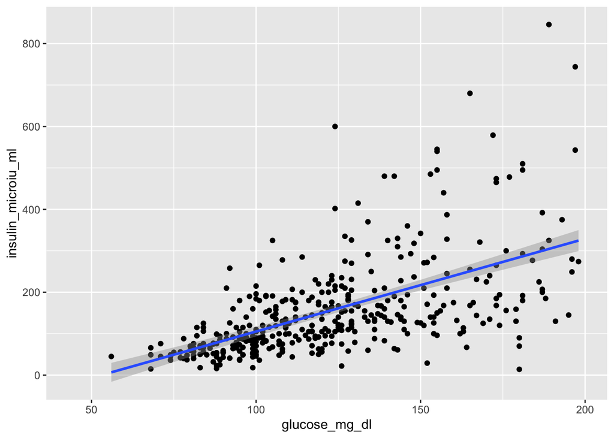

The glucose and insulin level seems to be dependent on each other.

### Plot 3: The level of glucose vs insulin depend against “diabetes_5_year”

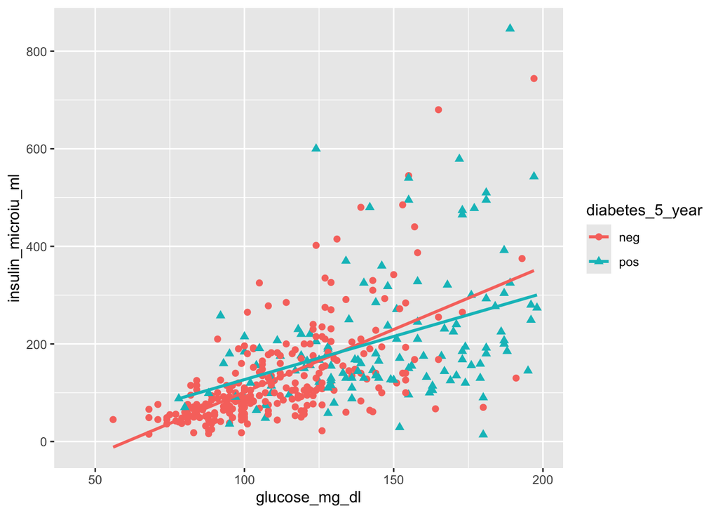

The level of glucose and insulin were correlated in both 5 year diabetes positive and negative patients, but the correlation seemed stronger in diabetes negative patients.

### Plot 4: The level of glucose vs blood pressure

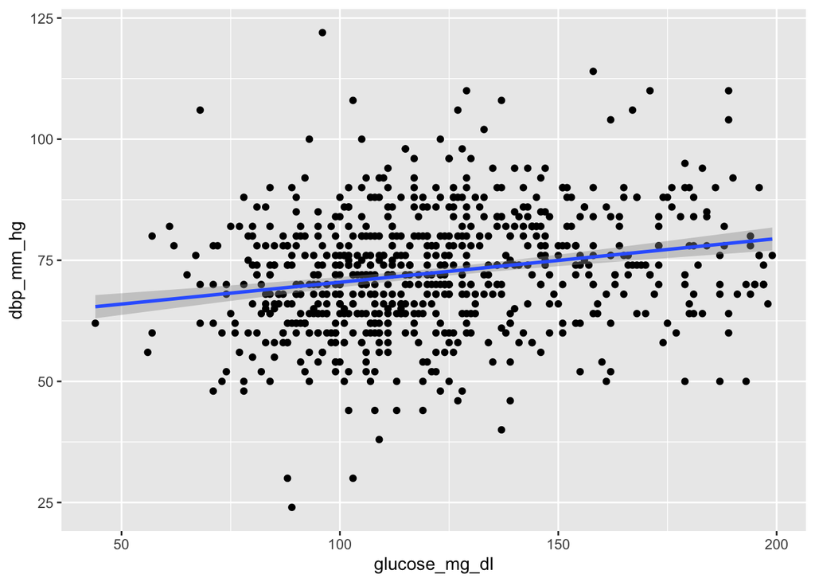

There does not seem to be strong correlation between glucose and blood pressure.

### Plot 5: BMI values vs triceps_mm values

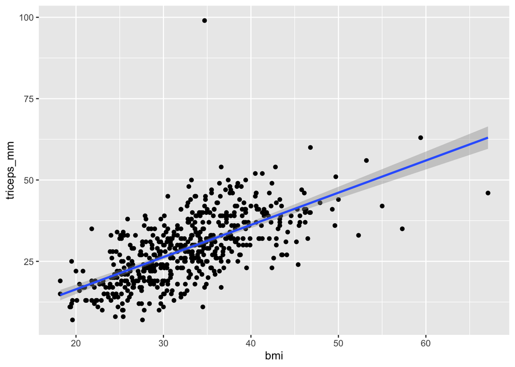

There was a strong relationship between BMI and triceps_mm.

### Plot 6: The blood pressure distribution in different BMI categories

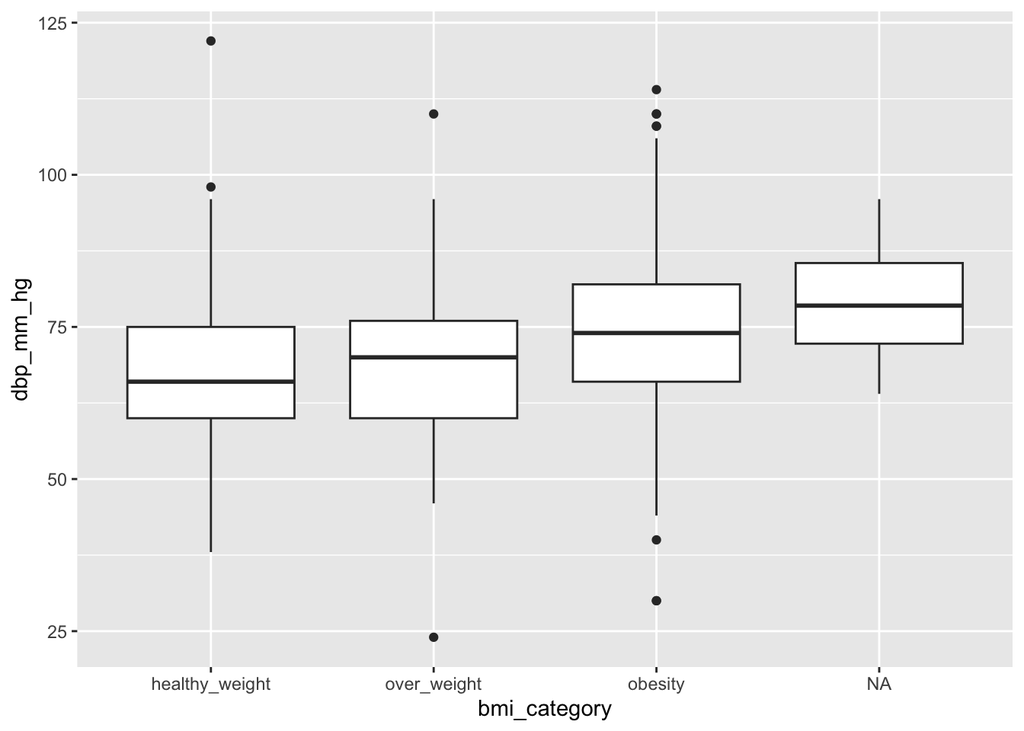

Blood pressure distributions tend to increase with higher obesity levels based on BMI categories. In patients with unknown BMI values, the pattern closely resembles that of the obesity group.

## STATISTICAL ANALYSIS

We analysed the datasets to check if diabetes outcome were dependent on the following 4 variables:

### Statistical test 1: Diabetes status against pedigree status

```
## # A tibble: 1 × 4
##   statistic p.value parameter method
##       <dbl>   <dbl>     <int> <chr>
## 1      532.   0.300       516 Kruskal-Wallis rank sum test
```

- The effect of pedigree on diabetes outcome was not statistically significant so diabetes does not seems to be effected by pedigree

### Statistical test 2: Diabetes status against BMI values

```
## # A tibble: 1 × 4
##   statistic p.value parameter method
##       <dbl>   <dbl>     <int> <chr>
## 1      284.  0.0490       246 Kruskal-Wallis rank sum test
```

- The effect of BMI on diabetes was statistically significant so diabetes seems to be effected by BMI

### Statistical test 3: Diabetes status against Glucose levels:

```
## # A tibble: 1 × 4
##   statistic  p.value parameter method
##       <dbl>    <dbl>     <int> <chr>
## 1      269. 3.84e-11       134 Kruskal-Wallis rank sum test
```

- The effect of glucose_mg_dl on diabetes was statistically significant so so diabetes seems to be effected by glucose levels

### Statistical test 4: Diabetes status against Hospitals:

```
## # A tibble: 1 × 4
##   statistic p.value parameter method
##       <dbl>   <dbl>     <int> <chr>
## 1      2.42   0.298         2 Kruskal-Wallis rank sum test
```